# Лабораторная работа №2

Операционные сисетмы

Никуленков С.С

Российский университет дружбы народов, Москва, Россия

Объединённый институт ядерных исследований, Дубна, Россия

## Цель работы

Изучить идеологию и применение средств контроля версий. Освоить умения по работе с git.

## Задание

1. Создать базовую конфигурацию для работы с git.
2. Создать ключ SSH.
3. Создать ключ PGP.
4. Настроить подписи git.
5. Зарегистрироваться на Github.
6. Создать локальный каталог для выполнения заданий по предмету.

## установка git

Установливаю git: dnf install git

[figure not shown]

установка

## установка gh

Устанавливаю gh: dnf install gh

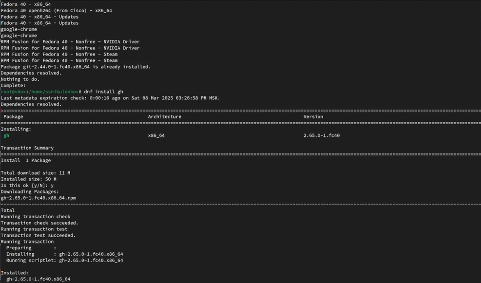

установка

## Настройка git

Базовая настройка git

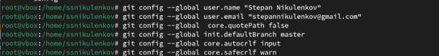

базовая настройка git

## Создание ключей

Создаю ключи ssh по алгоритму rsa с ключём размером 4096 бит: ssh-keygen -t rsa -b 4096 по алгоритму ed25519: ssh-keygen -t ed25519 Создаю ключи pgp Генерируем ключ gpg –full-generate-key

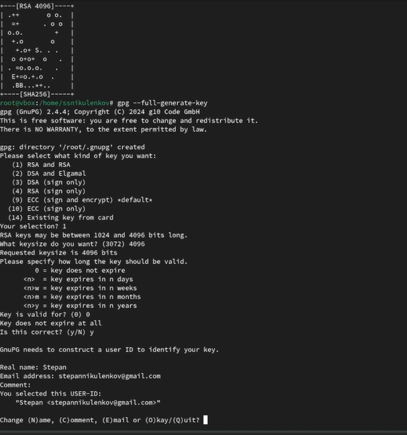

создание ключей

## Создание ключей

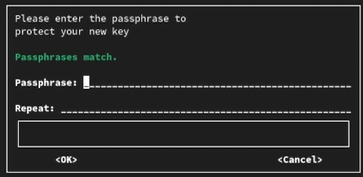

окно подтверждения

## Создание ключей

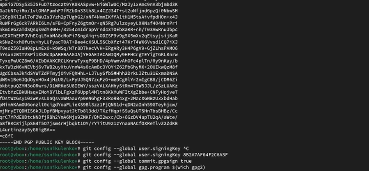

ключ

## Добавление ключей

Выводим список ключей и копируем отпечаток приватного ключа.Cкопировал сгенерированный PGP ключ в буфер обмена:

gpg –armor –export | xclip -sel clip

Перехожу в настройки GitHub , нажмимаю на кнопку New GPG key и вставьте полученный ключ в поле ввода.

[figure not shown]

копирование ключа

## Создание ключей

[figure not shown]

добавление ключа

## авторизация

Авторизуюсь через браузер

## Создание репозитория

создание репозитория курса на основе шаблона прописываю комнды для создания репозитория:

mkdir -p ~/work/study/2024-2025/“Операционные системы” cd ~/work/study/2024-2025/“Операционные системы” gh repo create study_2024-2025_os-intro –template=yamadharma/course-directory-student-template –public git clone –recursive git@github.com:/study_2024-2025_os-intro.git os-intro

[figure not shown]

создание репозитория

## Настройка каталога курса

Перехожу в каталог курса:

cd ~/work/study/2024-2025/“Операционные системы”/os-intro

Удаляю лишние файлы:

rm package.json

Отправляю файлы на сервер:

git add . git commit -am ‘feat(main): make course structure’ git push

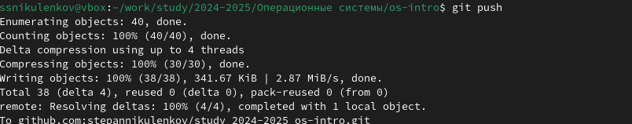

отправка на сервер

## Выводы

Я изучил идеологию и применение средств контроля версий. Освоил умения по работе с git.